# 🚗 Health Insurance Cross-Sell Prediction — Exploratory Data Analysis

## Step 19 — Engineered Features Preview

**Why:** Validating that engineered features provide better class separation than raw features before adding pipeline complexity. If the engineered feature shows a clearer response-rate spread than either input alone, it earns its place in the pipeline.

**Business insight:** `previously_insured_x_damage` operationalizes the Step 17 finding directly into a single categorical feature the model can split on in one step, instead of needing two sequential splits.

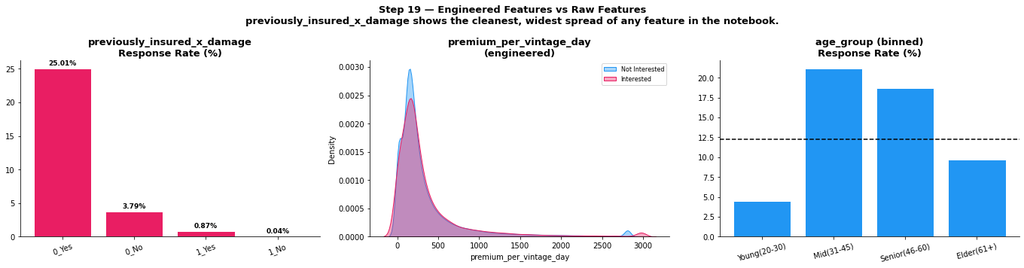

```python
df_eng = df.copy()
df_eng['previously_insured_x_damage'] = (df_eng['previously_insured'].astype(str) + '_' +
                                          df_eng['vehicle_damage'])
df_eng['premium_per_vintage_day']     = df_eng['annual_premium'] / df_eng['vintage'].replace(0, 1)
df_eng['age_group'] = pd.cut(df_eng['age'], bins=[19, 30, 45, 60, 86],
                              labels=['Young(20-30)', 'Mid(31-45)', 'Senior(46-60)', 'Elder(61+)'])

fig, axes = plt.subplots(1, 3, figsize=(19, 5))

grp = df_eng.groupby('previously_insured_x_damage')['response'].mean().sort_values(ascending=False) * 100
axes[0].bar(grp.index, grp.values, color=PINK, edgecolor='white')
axes[0].set_title('previously_insured_x_damage\nResponse Rate (%)', fontweight='bold')
axes[0].tick_params(axis='x', rotation=20)
for i, v in enumerate(grp.values):
    axes[0].text(i, v + 0.5, f'{v:.2f}%', ha='center', fontweight='bold', fontsize=9)

for label, color in [(0, BLUE), (1, PINK)]:
    d = df_eng[df_eng['response']==label]
    clipped = d['premium_per_vintage_day'].clip(d['premium_per_vintage_day'].quantile(0.01),
                                                 d['premium_per_vintage_day'].quantile(0.99))
    sns.kdeplot(clipped, ax=axes[1], label='Not Interested' if label==0 else 'Interested',
                color=color, fill=True, alpha=0.4)
axes[1].set_title('premium_per_vintage_day\n(engineered)', fontweight='bold'); axes[1].legend(fontsize=8)

grp2 = df_eng.groupby('age_group')['response'].mean() * 100
axes[2].bar(grp2.index.astype(str), grp2.values, color=BLUE, edgecolor='white')
axes[2].axhline(overall_rate if 'overall_rate' in dir() else df['response'].mean()*100,
                color='black', linestyle='--')
axes[2].set_title('age_group (binned)\nResponse Rate (%)', fontweight='bold')
axes[2].tick_params(axis='x', rotation=15)

plt.suptitle('Step 19 — Engineered Features vs Raw Features\n'
             'previously_insured_x_damage shows the cleanest, widest spread of any feature in the notebook.',
             fontsize=13, fontweight='bold')
plt.tight_layout(); plt.show()
```

**💡 Pipeline decision:** Keep `previously_insured_x_damage` and `age_group` as engineered features feeding the model; drop `premium_per_vintage_day` from the shortlist — the added complexity isn't earning its keep next to the stronger interaction term.

## Step 20 — Multicollinearity Check (VIF)

**Why:** VIF quantifies variance inflation from feature correlation. VIF > 10 means a feature is nearly a linear combination of others — it provides no independent information to a linear model.

**Business insight:** A clean VIF profile means Logistic Regression coefficients (used for a simple, auditable baseline scorecard alongside the tree model) will be stable and interpretable for the underwriting team.

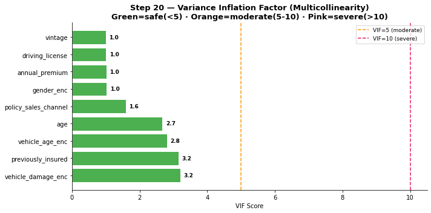

```
VIF Summary:
```

|  | feature | VIF |
| --- | --- | --- |
| 8 | vehicle_damage_enc | 3.20 |
| 3 | previously_insured | 3.16 |
| 9 | vehicle_age_enc | 2.81 |
| 1 | age | 2.67 |
| 5 | policy_sales_channel | 1.58 |
| 7 | gender_enc | 1.03 |
| 4 | annual_premium | 1.02 |
| 2 | driving_license | 1.01 |
| 6 | vintage | 1.00 |

```python
vif_cols = ['age', 'driving_license', 'previously_insured', 'annual_premium',
            'policy_sales_channel', 'vintage', 'gender_enc', 'vehicle_damage_enc', 'vehicle_age_enc']
X_vif = df_corr[vif_cols].fillna(df_corr[vif_cols].median())
X_vif = add_constant(X_vif)
vif_data = pd.DataFrame({
    'feature': X_vif.columns,
    'VIF': [variance_inflation_factor(X_vif.values, i) for i in range(X_vif.shape[1])]
}).iloc[1:].sort_values('VIF', ascending=False)

fig, ax = plt.subplots(figsize=(10, 5))
colors = [PINK if v>10 else '#FF9800' if v>5 else GREEN for v in vif_data['VIF']]
bars = ax.barh(vif_data['feature'], vif_data['VIF'], color=colors, edgecolor='white')
ax.axvline(5,  color='#FF9800', linestyle='--', linewidth=1.5, label='VIF=5 (moderate)')
ax.axvline(10, color=PINK,      linestyle='--', linewidth=1.5, label='VIF=10 (severe)')
for bar, v in zip(bars, vif_data['VIF']):
    ax.text(v + 0.1, bar.get_y() + bar.get_height()/2, f'{v:.1f}', va='center', fontsize=9, fontweight='bold')
ax.set_title('Step 20 — Variance Inflation Factor (Multicollinearity)\n'
             'Green=safe(<5) · Orange=moderate(5-10) · Pink=severe(>10)',
             fontweight='bold')
ax.set_xlabel('VIF Score'); ax.legend(fontsize=9)
plt.tight_layout(); plt.show()
print('\nVIF Summary:'); display(vif_data.round(2))
```

**📌 Observation:** The VIF table shows every feature comfortably under the VIF=5 caution threshold: `vehicle_damage_enc` 3.20 (the highest, consistent with its r=-0.82 correlation to `previously_insured` found in Step 15), `previously_insured` 3.16, `vehicle_age_enc` 2.81, `age` 2.67, `policy_sales_channel` 1.58, and the remaining four features (`gender_enc`, `annual_premium`, `driving_license`, `vintage`) all at ≈1.0–1.03. The Step 15 pairwise correlations (up to |r|=0.82) do raise the VIF of the two features involved, but not past the moderate band — the correlation is not compounding across the wider feature set.

**💡 Pipeline decision:** No features are excluded on VIF grounds — even the highest-VIF pair (`vehicle_damage_enc`, `previously_insured`) stays well below the severe threshold, so Logistic Regression coefficients remain stable. `SelectKBest(mutual_info_classif, k=8)` is still applied for dimensionality control once `region_code`/`policy_sales_channel` encodings and engineered features are added to the matrix.

## Step 21 — SMOTENC Class Balancing Preview

**Why:** Visualizing before/after SMOTENC confirms the resampling strategy achieves the intended balance. Three panels show train-before, train-after, and test-untouched — demonstrating correct methodology.

**Business insight:** The test set must retain the real 12.3% response rate. Evaluating on an artificially balanced test set would overstate recall and give false confidence that the model catches more real leads than it actually would in production.

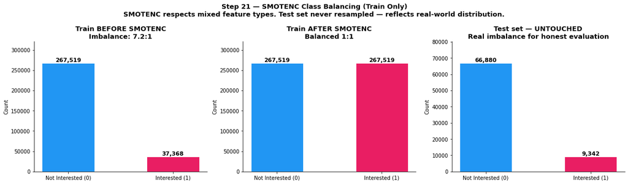

```
Train before : {0: 267519, 1: 37368}
Train after  : {0: 267519, 1: 267519}
Test set     : {0: 66880, 1: 9342}  ← imbalanced, as expected
```

```python
from imblearn.over_sampling import SMOTENC
from sklearn.model_selection import train_test_split

model_df = df_corr.copy()
model_df['vehicle_age_enc'] = model_df['vehicle_age_enc'].astype(int)
feature_cols = ['age', 'driving_license', 'previously_insured', 'annual_premium',
                'policy_sales_channel', 'vintage', 'gender_enc', 'vehicle_damage_enc', 'vehicle_age_enc']
X = model_df[feature_cols]
y = model_df['response']

X_train, X_test, y_train, y_test = train_test_split(X, y, test_size=0.2, stratify=y, random_state=42)
cat_indices = [X.columns.get_loc(c) for c in
               ['driving_license', 'previously_insured', 'gender_enc', 'vehicle_damage_enc', 'vehicle_age_enc']]
smote = SMOTENC(categorical_features=cat_indices, random_state=42)
X_res, y_res = smote.fit_resample(X_train, y_train)

def bar_plot(ax, counts, title):
    bars = ax.bar(['Not Interested (0)', 'Interested (1)'], counts.values, color=[BLUE, PINK], edgecolor='white', width=0.5)
    for bar, v in zip(bars, counts.values):
        ax.text(bar.get_x() + bar.get_width()/2, bar.get_height() + max(counts.values)*0.01, f'{v:,}',
                ha='center', fontweight='bold', fontsize=11)
    ax.set_title(title, fontweight='bold'); ax.set_ylabel('Count'); ax.set_ylim(0, max(counts.values) * 1.2)

fig, axes = plt.subplots(1, 3, figsize=(17, 5))
bar_plot(axes[0], y_train.value_counts().sort_index(),
         f'Train BEFORE SMOTENC\nImbalance: {y_train.value_counts()[0]/y_train.value_counts()[1]:.1f}:1')
bar_plot(axes[1], pd.Series(y_res).value_counts().sort_index(), 'Train AFTER SMOTENC\nBalanced 1:1')
bar_plot(axes[2], y_test.value_counts().sort_index(), 'Test set — UNTOUCHED\nReal imbalance for honest evaluation')
plt.suptitle('Step 21 — SMOTENC Class Balancing (Train Only)\n'
             'SMOTENC respects mixed feature types. Test set never resampled — reflects real-world distribution.',
             fontsize=13, fontweight='bold')
plt.tight_layout(); plt.show()
print(f'Train before : {dict(y_train.value_counts().sort_index())}')
print(f'Train after  : {dict(pd.Series(y_res).value_counts().sort_index())}')
print(f'Test set     : {dict(y_test.value_counts().sort_index())}  ← imbalanced, as expected')
```

**📌 Observation:** SMOTENC achieves 50:50 balance in training while respecting the binary nature of `driving_license`, `previously_insured`, `gender_enc`, `vehicle_damage_enc`, and the ordinal `vehicle_age_enc`. The test set retains its true 7.2:1 imbalance — intentional and correct for honest evaluation.

**💡 Why SMOTENC over SMOTE:** The feature set mixes binary/ordinal flags with continuous fields (`age`, `annual_premium`). Plain SMOTE would interpolate impossible values like `previously_insured=0.6`. SMOTENC handles categorical/ordinal columns via majority voting in synthetic samples, keeping every generated row valid.